# Chapter 2: Regression and Model Validation.

## 2.1.Data Analysis.

### 2.1.1.Reading of the dataframe “learning2014” and exploration of its dimension and structure.

First of all, I read the new dataframe with the function `read.table()`.

Then I use of the function `dim()` to show the dimension of the dataframe that is of 166 objects and 7 variables as explained in the above-mentioned data wrangling section:

```
## [1] 166   7
```

By typing the function `str()`, it shows the structure of the dataframe:

```
## 'data.frame':    166 obs. of  7 variables:
##  $ gender  : Factor w/ 2 levels "F","M": 1 2 1 2 2 1 2 1 2 1 ...
##  $ Age     : int  53 55 49 53 49 38 50 37 37 42 ...
##  $ Attitude: num  3.7 3.1 2.5 3.5 3.7 3.8 3.5 2.9 3.8 2.1 ...
##  $ deep    : num  3.58 2.92 3.5 3.5 3.67 ...
##  $ stra    : num  3.38 2.75 3.62 3.12 3.62 ...
##  $ surf    : num  2.58 3.17 2.25 2.25 2.83 ...
##  $ Points  : int  25 12 24 10 22 21 21 31 24 26 ...
```

### 2.1.2.Graphical overview of the data and summary of their variables.

To visualize the data I type the functions `install.packages()` to install the visualization packages `ggplot2` and `GGally`. Then by using the function `library()` I open them in the project.

install.packages(“ggplot2”)  
install.packages(“GGally”)  
library(ggplot2)

#### Visualizing and Exploring the dataframe.

The libraries are opened:

By using the fast plotting function `pairs()`, we can see a scatterplot matrix resulting from the draws of all the possible scatterplots from the columns of the dataframe. Different colors are used for males and females.

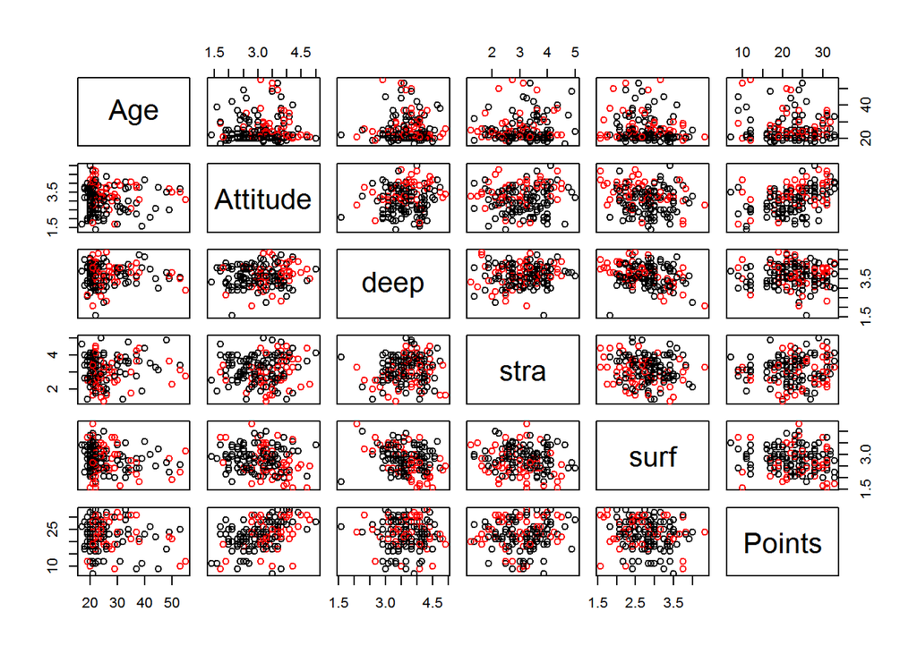

This second plot matrix is more advanced, and it is made with `ggpairs()`.

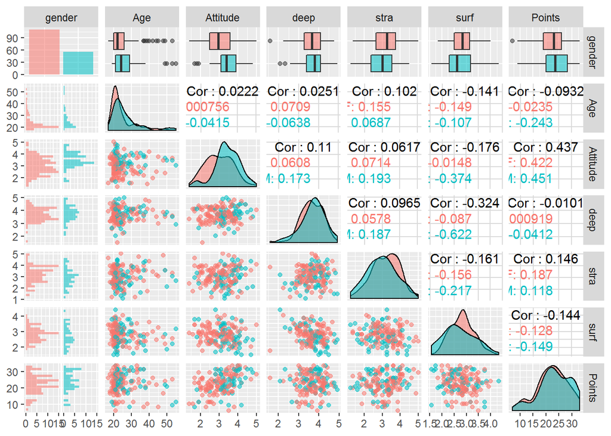

The summary of the variables:

```
##  gender       Age           Attitude          deep            stra
##  F:110   Min.   :17.00   Min.   :1.400   Min.   :1.583   Min.   :1.250
##  M: 56   1st Qu.:21.00   1st Qu.:2.600   1st Qu.:3.333   1st Qu.:2.625
##          Median :22.00   Median :3.200   Median :3.667   Median :3.188
##          Mean   :25.51   Mean   :3.143   Mean   :3.680   Mean   :3.121
##          3rd Qu.:27.00   3rd Qu.:3.700   3rd Qu.:4.083   3rd Qu.:3.625
##          Max.   :55.00   Max.   :5.000   Max.   :4.917   Max.   :5.000
##       surf           Points
##  Min.   :1.583   Min.   : 7.00
##  1st Qu.:2.417   1st Qu.:19.00
##  Median :2.833   Median :23.00
##  Mean   :2.787   Mean   :22.72
##  3rd Qu.:3.167   3rd Qu.:27.75
##  Max.   :4.333   Max.   :33.00
```

#### Output interpretation and description, distribution of the variables and their in-between relations.

The females are almost double of the males who present a wider age range. The summary suggest a significant correlation for surf vs deep and points vs attitude.

### 2.1.3.Multiple Regression Model.

I have chosen three variables “attitude”, “deep learning” and “surface learning”, with the target variable “exam points” to fit a regression model analysis.

Drawing a plot matrix with `ggpairs()`.

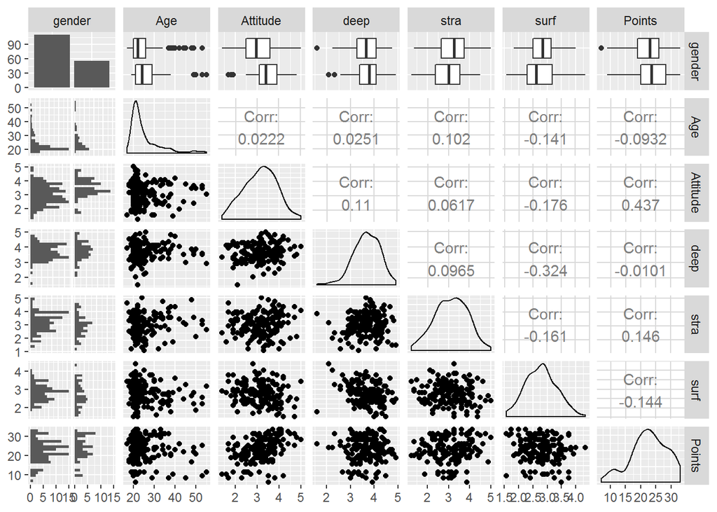

Fitting the regression models with three explanatory variables and running the summary:

```
##
## Call:
## lm(formula = Points ~ Attitude + deep + surf, data = learning2014)
##
## Residuals:
##      Min       1Q   Median       3Q      Max
## -16.9168  -3.1487   0.3667   3.8326  11.3519
##
## Coefficients:
##             Estimate Std. Error t value Pr(>|t|)
## (Intercept)  18.3551     4.7124   3.895 0.000143 ***
## Attitude      3.4661     0.5766   6.011 1.18e-08 ***
## deep         -0.9485     0.7903  -1.200 0.231815
## surf         -1.0911     0.8360  -1.305 0.193669
## ---
## Signif. codes:  0 '***' 0.001 '**' 0.01 '*' 0.05 '.' 0.1 ' ' 1
##
## Residual standard error: 5.313 on 162 degrees of freedom
## Multiple R-squared:  0.2024, Adjusted R-squared:  0.1876
## F-statistic:  13.7 on 3 and 162 DF,  p-value: 5.217e-08
```

#### 2.1.4.Explanation of the relationships between the chosen explanatory variables and the target variable. With the summary of the fitted model (interpret the model parameters). Explaination and interpretation of the multiple R squared of the model.

The adjusted R square of 0.1876 denotes a poorly fitting function to the explanatory variables. Only attitude presents statistical significance.

### 2.1.5.Diagnostic plots

#### Residuals *vs* Fitted values.

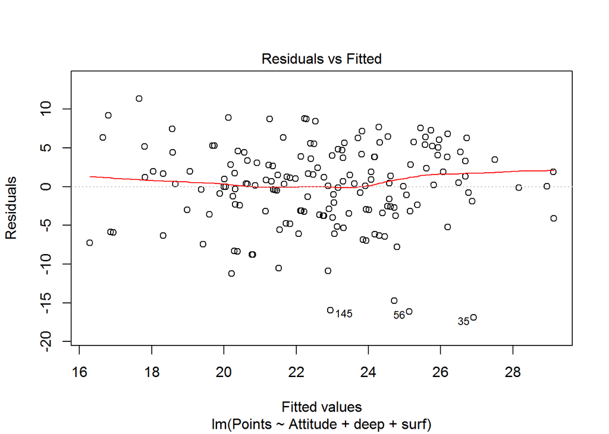

#### Normal QQ-plot.

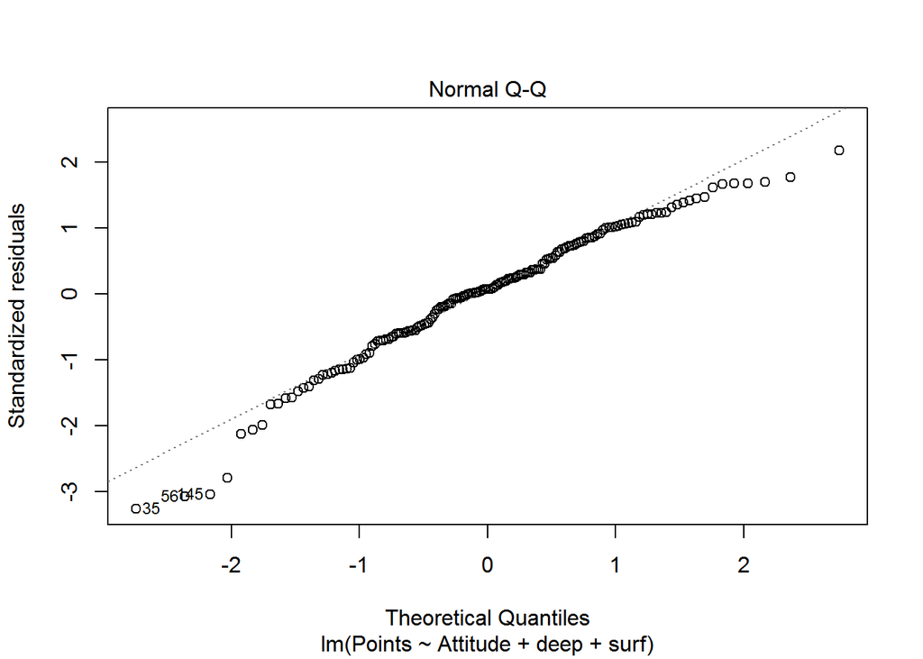

#### Residuals *vs* Leverage.

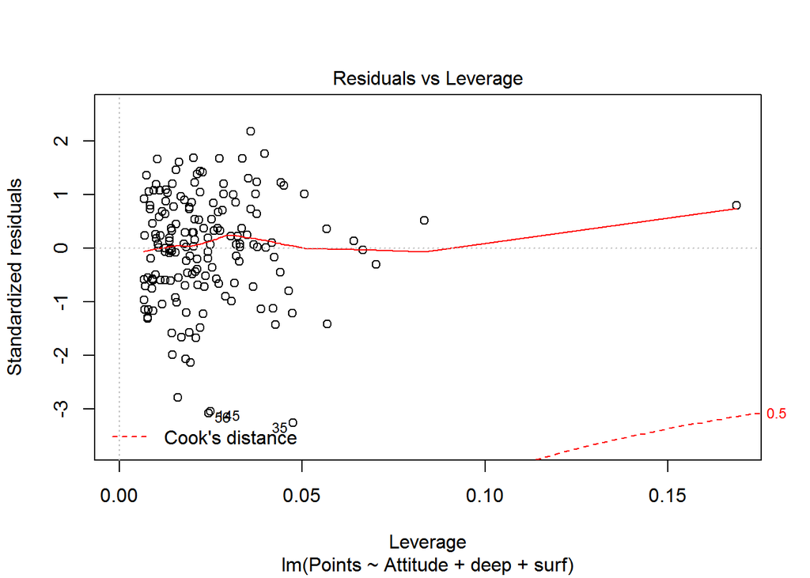

#### **Explanation of the model’s assumptions and interpretation of their validity on the bases of the diagnostic plots.**

A Multiple Linear Regression Model has few assumptions:  
a *linear relationship* between the target variable and the explanatory variables, usually revealed by scatterplots;  
a *multivariate normality*, which means that the residuals are normally distributed. The QQ-plot can reveal it;  
the *absence of multicollinearity*, in other words, the explanatory variables are not highly correlated to each other.  
*homoscedasticity*: or constant variance of errors. There is a similar variance of error terms across the values of the explanatory variable. A plot of standardized residuals versus predicted values shows if the points are equally distributed across all values of the dependent variables.  
The diagnostic plots delivered the following observations:  
In the **residuals *vs* fitted values**, the plot is utilized to check the assumption of linear relationship. An horizontal line, without distinct patterns is an indicator for a linear relationship, in this case, the red line is more or less horizontal at zero. Hence here linear relationship could be assumed.  
In the **normal QQ-plot** the plot reveals the presence of multivariate normality. A good indication is if the residual points follow the straight dashed line. For the majority it is the case here, hence normality can also be assumed.  
In the **residuals *vs* leverage**, the plot identifies the impact of a single observation on the model. Influential points lie at the upper or at the lower right corner in a position where they are influential against a regression line. In this case the points are on the left side of the plot, thus we can say that there is no leverage.